# HeapSort

Prof. Juliano Foleis

## Construção da Heap

A construção da heap é o procedimento usado para converter um vetor $V[1\dots n]$ qualquer em uma heap-máxima.

## Corretude do `BUILD-MAX-HEAP`

Este algoritmo está correto somente se ao final da execução o vetor $V[1\dots n]$ for uma heap máxima, ou seja, se o nó na posição 1 for raíz de uma heap-máxima.

**Invariante:**

No início de cada iteração do laço `FOR` das linhas 2–3, todos os nós das posições $i+1, i+2, \dots, n$ são raízes de heaps-máximas.

## Corretude do `BUILD-MAX-HEAP`

```
PROCEDURE BUILD-MAX-HEAP(V, n)
FOR i = CHAO(n/2) DOWNTO 1 DO
  MAX-HEAPIFY(V, i, n)
```

**Invariante:** No início de cada iteração do laço `FOR` das linhas 2–3, todos os nós das posições $i+1, i+2, \dots, n$ são raízes de heaps-máximas.

**Inicialização:** Antes da primeira iteração, $i = \left \lfloor \frac{n}{2} \right \rfloor$. Substituindo na invariante, temos:

Todos os nós das posições $\left \lfloor \frac{n}{2} \right \rfloor + 1, \left \lfloor \frac{n}{2} \right \rfloor + 2, \dots n$ são raízes de heaps máximas.

Sabemos que todos os nós das posições $\left \lfloor \frac{n}{2} \right \rfloor + 1, \left \lfloor \frac{n}{2} \right \rfloor + 2, \dots n$ são folhas, e portanto, raízes de heaps-máximas triviais. Portanto, é possível concluir que a invariante é verdadeira.

## Corretude do `BUILD-MAX-HEAP`

```
PROCEDURE BUILD-MAX-HEAP(V, n)
FOR i = CHAO(n/2) DOWNTO 1 DO
  MAX-HEAPIFY(V, i, n)
```

**Invariante:** No início de cada iteração do laço `FOR` das linhas 2–3, todos os nós das posições $i+1, i+2, \dots, n$ são raízes de heaps-máximas.

**Manutenção:** Supondo que a invariante é verdadeira no início da iteração $i$, sabemos que todos os nós das posições $i+1, i+2, \dots, n$ são raízes de heaps-máximas. Portanto, a pré-condição para invocar `MAX-HEAPIFY` na posição $i$ é satisfeita, uma vez que os filhos do nó estão em posições maiores que $i$. Sabemos que `MAX-HEAPIFY` torna o nó da posição $i$ a raíz de uma heap máxima, mantendo os nós nas posições subsequentes como raízes de heaps máximas. Desta forma, sabemos que:

Todos os nós das posições *i, i+1, i+2, … , n* são raízes de heaps-máximas.

Após o decremento do $i$ a invariante é reestabelecida para a próxima iteração:

Todos os nós das posições *i+1, i+2, i+3, … , n* são raízes de heaps-máximas.

## Corretude do `BUILD-MAX-HEAP`

```
PROCEDURE BUILD-MAX-HEAP(V, n)
FOR i = CHAO(n/2) DOWNTO 1 DO
  MAX-HEAPIFY(V, i, n)
```

**Invariante:** No início de cada iteração do laço `FOR` das linhas 2–3, todos os nós das posições $i+1, i+2, \dots, n$ são raízes de heaps-máximas.

**Término:** Após a última iteração do laço `FOR`, $i=0$. Pela invariante de laço, todos os nós nas posições $i+1, i+2, i+3, \dots, n$ são raízes de heaps-máximas. Substituindo $i$, sabemos que todos os nós nas posições $1, 2, 3, \dots, n$ são raízes de heaps-máximas.

Como o nó na posição $1$ é raíz de heap-máxima, então temos que o vetor V tornou-se uma heap máxima. Desta forma, o algoritmo está correto.

## Desempenho de `BUILD-MAX-HEAP`

Um limite assintótico superior de `BUILD-MAX-HEAP` pode ser estimado da seguinte forma: cada chamada a `MAX-HEAPIFY` tem custo $O(\lg n)$ e `BUILD-MAX-HEAP` faz $O(n)$ chamadas delas. Desta forma, $T(n) = O(n) \cdot O(\lg n) = O(n \lg n)$ descreve o limite assintótico superior.

Contudo, embora correto, este limite não está ajustado o máximo possível.

## Desempenho de `BUILD-MAX-HEAP`

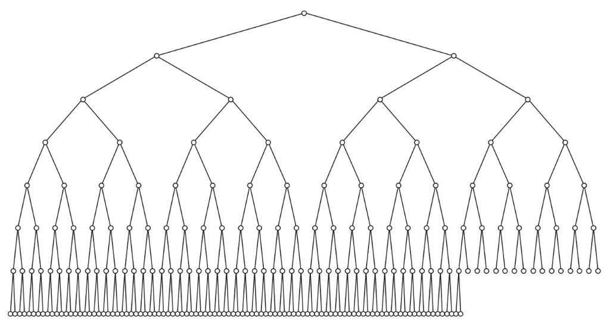

## Desempenho de `BUILD-MAX-HEAP`

Podemos encontrar o limite ajustado observando que **o tempo gasto por `MAX-HEAPIFY` varia de acordo com a altura do nó na árvore**, e que a altura da maioria dos nós é pequena (tende a uma constante).

Esta análise mais refinada está embasada nas propriedades que uma heap com com $n$ elementos possui altura $\lfloor \lg n \rfloor$, e no máximo, $\left \lceil \left ( \frac{n}{2^{h+1}} \right ) \right \rceil$ nós em uma altura $h$. Assim, o tempo necessário para `MAX-HEAPIFY` executar em um nó de altura $h$ é $O(h)$, portanto o custo de `BUILD-MAX-HEAP` está limitada superiormente por:

$$T(n) = \sum_{h = 0}^{\lfloor \lg n \rfloor} \left \lceil \frac{n}{2^{h+1}} \right \rceil O(h)$$

## Desempenho de `BUILD-MAX-HEAP`

$$\begin{align}
T(n) & = \sum_{h = 0}^{\lfloor \lg n \rfloor} \left ( \frac{n}{2^{h+1}} \right ) h\\
& = \frac{n}{2} \sum_{h = 0}^{\lfloor \lg n \rfloor} \left ( \frac{h}{2^h} \right )
\end{align}$$

$$\begin{align}
T(n) & = \frac{n}{2} \sum_{h = 0}^{\lfloor \lg n \rfloor} \left ( \frac{h}{2^h} \right )\\
& \leq \frac{n}{2} \sum_{h = 0}^{\infty} \left ( \frac{h}{2^h} \right )
\end{align}$$

como

$$\sum_{h=0}^{\infty} \frac{h}{2^h} = \frac{\frac{1}{2}}{(1-\frac{1}{2})^2} = 2$$

$$\begin{align}
T(n) & \leq \frac{n}{2} \sum_{h = 0}^{\infty} \left ( \frac{h}{2^h} \right )\\
& \leq \frac{n}{2} (2) \\
& \leq n \\
\end{align}$$
e

Portanto, $T(n) = O(n)$.

## Bibliografia

[CRLS] CORMEN, T. H. et al. Algoritmos: Teoria e Prática. Elsevier, 2012. 3a Ed. Capítulo 6 (Ordenação por Heap), Seções 6.1–6.4.